# Laboratorio 2 CA0411

Author

Joshua Cervantes Artavia

Published

3/18/25

# Descripción del laboratorio

En este laboratorio se va buscar diseñar nuestro propio ACP normado de tal forma que lo podamos estimar a “mano”.

Recordemos que en este caso que la forma de obtener el ACP era diagonalizando o obtiniendo los autovarlores y autovectores de la matriz de correlaciones. Más adelante se va ver una versión más general de nuestro ACP.

```python
#Se carga el modulo
from cod.acp import ACP_normado
import pandas as pd
import numpy as np
import matplotlib.pyplot as plt
import seaborn as sns
```

# Carga de datos

Una vez más vamos a usar nuestra tabla de datos de casas de Boston.

```python
from ISLP import load_data # Modulo con los datos

# Carga de datos
df_boston = load_data("Boston")
```

En este caso recordamos que la variable chas es categorica y este ACP es solo para variables numéricas entonces la vamos a eliminar.

```python
#Se procede a eliminar la variable
df_boston = df_boston.drop(["chas"], axis =1 )
```

# Uso del módulo

```python
#Primero vamos a tener que estandarizar los datos
from sklearn.preprocessing import StandardScaler

scaler = StandardScaler()

#Lo ajustamos a los datos
scaler.fit(df_boston)

#Transformamos los datos

df_boston_std =  pd.DataFrame(scaler.transform(df_boston), columns=df_boston.columns)



df_boston_std
```

|  | crim | zn | indus | nox | rm | age | dis | rad | tax | ptratio | lstat | medv |
| --- | --- | --- | --- | --- | --- | --- | --- | --- | --- | --- | --- | --- |
| 0 | -0.419782 | 0.284830 | -1.287909 | -0.144217 | 0.413672 | -0.120013 | 0.140214 | -0.982843 | -0.666608 | -1.459000 | -1.075562 | 0.159686 |
| 1 | -0.417339 | -0.487722 | -0.593381 | -0.740262 | 0.194274 | 0.367166 | 0.557160 | -0.867883 | -0.987329 | -0.303094 | -0.492439 | -0.101524 |
| 2 | -0.417342 | -0.487722 | -0.593381 | -0.740262 | 1.282714 | -0.265812 | 0.557160 | -0.867883 | -0.987329 | -0.303094 | -1.208727 | 1.324247 |
| 3 | -0.416750 | -0.487722 | -1.306878 | -0.835284 | 1.016303 | -0.809889 | 1.077737 | -0.752922 | -1.106115 | 0.113032 | -1.361517 | 1.182758 |
| 4 | -0.412482 | -0.487722 | -1.306878 | -0.835284 | 1.228577 | -0.511180 | 1.077737 | -0.752922 | -1.106115 | 0.113032 | -1.026501 | 1.487503 |
| ... | ... | ... | ... | ... | ... | ... | ... | ... | ... | ... | ... | ... |
| 501 | -0.413229 | -0.487722 | 0.115738 | 0.158124 | 0.439316 | 0.018673 | -0.625796 | -0.982843 | -0.803212 | 1.176466 | -0.418147 | -0.014454 |
| 502 | -0.415249 | -0.487722 | 0.115738 | 0.158124 | -0.234548 | 0.288933 | -0.716639 | -0.982843 | -0.803212 | 1.176466 | -0.500850 | -0.210362 |
| 503 | -0.413447 | -0.487722 | 0.115738 | 0.158124 | 0.984960 | 0.797449 | -0.773684 | -0.982843 | -0.803212 | 1.176466 | -0.983048 | 0.148802 |
| 504 | -0.407764 | -0.487722 | 0.115738 | 0.158124 | 0.725672 | 0.736996 | -0.668437 | -0.982843 | -0.803212 | 1.176466 | -0.865302 | -0.057989 |
| 505 | -0.415000 | -0.487722 | 0.115738 | 0.158124 | -0.362767 | 0.434732 | -0.613246 | -0.982843 | -0.803212 | 1.176466 | -0.669058 | -1.157248 |

506 rows × 12 columns

Se puede observar que en este caso se tiene que los datos han sido estandarizados.

Ahora estos datos se pasan al ACP normado

```python
#Se genera el objeto
acp_normado = ACP_normado(df_boston_std)
```

```python
#Vemos los datos
acp_normado.data
```

|  | crim | zn | indus | nox | rm | age | dis | rad | tax | ptratio | lstat | medv |
| --- | --- | --- | --- | --- | --- | --- | --- | --- | --- | --- | --- | --- |
| 0 | -0.419782 | 0.284830 | -1.287909 | -0.144217 | 0.413672 | -0.120013 | 0.140214 | -0.982843 | -0.666608 | -1.459000 | -1.075562 | 0.159686 |
| 1 | -0.417339 | -0.487722 | -0.593381 | -0.740262 | 0.194274 | 0.367166 | 0.557160 | -0.867883 | -0.987329 | -0.303094 | -0.492439 | -0.101524 |
| 2 | -0.417342 | -0.487722 | -0.593381 | -0.740262 | 1.282714 | -0.265812 | 0.557160 | -0.867883 | -0.987329 | -0.303094 | -1.208727 | 1.324247 |
| 3 | -0.416750 | -0.487722 | -1.306878 | -0.835284 | 1.016303 | -0.809889 | 1.077737 | -0.752922 | -1.106115 | 0.113032 | -1.361517 | 1.182758 |
| 4 | -0.412482 | -0.487722 | -1.306878 | -0.835284 | 1.228577 | -0.511180 | 1.077737 | -0.752922 | -1.106115 | 0.113032 | -1.026501 | 1.487503 |
| ... | ... | ... | ... | ... | ... | ... | ... | ... | ... | ... | ... | ... |
| 501 | -0.413229 | -0.487722 | 0.115738 | 0.158124 | 0.439316 | 0.018673 | -0.625796 | -0.982843 | -0.803212 | 1.176466 | -0.418147 | -0.014454 |
| 502 | -0.415249 | -0.487722 | 0.115738 | 0.158124 | -0.234548 | 0.288933 | -0.716639 | -0.982843 | -0.803212 | 1.176466 | -0.500850 | -0.210362 |
| 503 | -0.413447 | -0.487722 | 0.115738 | 0.158124 | 0.984960 | 0.797449 | -0.773684 | -0.982843 | -0.803212 | 1.176466 | -0.983048 | 0.148802 |
| 504 | -0.407764 | -0.487722 | 0.115738 | 0.158124 | 0.725672 | 0.736996 | -0.668437 | -0.982843 | -0.803212 | 1.176466 | -0.865302 | -0.057989 |
| 505 | -0.415000 | -0.487722 | 0.115738 | 0.158124 | -0.362767 | 0.434732 | -0.613246 | -0.982843 | -0.803212 | 1.176466 | -0.669058 | -1.157248 |

506 rows × 12 columns

Se puede observar que efectivamente se estan cargando los datos estandarizados.

```python
#Vemos la metrica
acp_normado.M
```

```
array([[1., 0., 0., 0., 0., 0., 0., 0., 0., 0., 0., 0.],
       [0., 1., 0., 0., 0., 0., 0., 0., 0., 0., 0., 0.],
       [0., 0., 1., 0., 0., 0., 0., 0., 0., 0., 0., 0.],
       [0., 0., 0., 1., 0., 0., 0., 0., 0., 0., 0., 0.],
       [0., 0., 0., 0., 1., 0., 0., 0., 0., 0., 0., 0.],
       [0., 0., 0., 0., 0., 1., 0., 0., 0., 0., 0., 0.],
       [0., 0., 0., 0., 0., 0., 1., 0., 0., 0., 0., 0.],
       [0., 0., 0., 0., 0., 0., 0., 1., 0., 0., 0., 0.],
       [0., 0., 0., 0., 0., 0., 0., 0., 1., 0., 0., 0.],
       [0., 0., 0., 0., 0., 0., 0., 0., 0., 1., 0., 0.],
       [0., 0., 0., 0., 0., 0., 0., 0., 0., 0., 1., 0.],
       [0., 0., 0., 0., 0., 0., 0., 0., 0., 0., 0., 1.]])
```

En este caso se puede observar que estamos usando la metrica definida por la identidad. Esto dado que estamos trabajando con datos estandarizados.

```python
acp_normado.mean()
```

```
crim      -1.123388e-16
zn         7.898820e-17
indus      2.106352e-16
nox       -1.965929e-16
rm        -1.088282e-16
age       -1.474446e-16
dis       -8.425408e-17
rad       -1.123388e-16
tax        0.000000e+00
ptratio   -4.212704e-16
lstat     -3.089316e-16
medv      -5.195668e-16
dtype: float64
```

Se puede observar que se obtiene el promedio por columna tal y como se quería.

```python
acp_normado.pca()
```

En este caso este atributo no va retornar nada, pero podríamos hacer una impresión indicando que se ejecuto de forma satisfactoria.

Se procede a ver la varianza explicada por las primerad dos componentes principales.

```python
acp_normado.explained_variance(2)
```

```
array([0.52694456, 0.12684227])
```

Se procede a ver las primeras componentes principales.

Primero se ven los autovalores y autovectores

```python
acp_normado.eig_vals
```

```
array([6.32333473, 1.52210728, 1.24947859, 0.82227137, 0.53916425,
       0.40453398, 0.06095433, 0.13623533, 0.28101464, 0.26327826,
       0.21352033, 0.18410689])
```

Se tienen los autovalores y todos son positivos como se esperaba, entre más alto el valor es mucho menor.

```python
acp_normado.eig_vecs
```

```
array([[-0.24272306,  0.02197122, -0.44681064,  0.20167081,  0.75283577,
        -0.18318828,  0.06091105, -0.10090983,  0.25150634, -0.1076646 ,
         0.07802658, -0.07172215],
       [ 0.25444883,  0.1253596 , -0.42083865,  0.44797309, -0.29870179,
         0.36407758, -0.09806573,  0.1317168 ,  0.45446529,  0.13239338,
         0.10938493,  0.23871004],
       [-0.33924082, -0.12022403,  0.05644497,  0.01002245, -0.35143201,
        -0.17244039, -0.23195307, -0.07599433,  0.52136854, -0.43123084,
        -0.26066094, -0.3586482 ],
       [-0.3314012 , -0.26257377,  0.08476255,  0.22906283, -0.19755046,
        -0.04125778,  0.09482302, -0.53758411, -0.09446479, -0.1713242 ,
         0.44314778,  0.43382231],
       [ 0.21050669, -0.52487749, -0.26202451, -0.20138544,  0.11159524,
         0.46015829,  0.00979585,  0.03538437, -0.17380466, -0.51623447,
        -0.1980308 ,  0.09750981],
       [-0.30532733, -0.2589754 ,  0.24032744,  0.06748948,  0.12648907,
         0.57719657, -0.03881382,  0.06917911,  0.07121819,  0.29750621,
         0.32912834, -0.46908399],
       [ 0.30601594,  0.37640079, -0.21330054,  0.04452206, -0.11254995,
         0.1296531 ,  0.05061427, -0.552713  , -0.2278537 , -0.18834158,
         0.14003093, -0.52217617],
       [-0.30549689, -0.07985778, -0.48255486, -0.08909727, -0.15546695,
        -0.07868455, -0.63329213, -0.00329854, -0.39502735,  0.26414746,
        -0.04041443, -0.02473913],
       [-0.32744578, -0.05288936, -0.4044515 , -0.01773576, -0.32990643,
        -0.07133922,  0.6989615 ,  0.2517568 , -0.16154299,  0.06166134,
        -0.03024027, -0.17151521],
       [-0.21369942,  0.32794618, -0.13225569, -0.73887321, -0.00318598,
         0.27362428,  0.05386982, -0.19327747,  0.3149846 ,  0.07343891,
         0.0817435 ,  0.23859918],
       [-0.31723169,  0.24218972,  0.13208248,  0.30230814,  0.08231183,
         0.35458753,  0.08777777, -0.25790813, -0.14808489,  0.09945191,
        -0.68448824,  0.15747744],
       [ 0.27091353, -0.49069557, -0.09795689, -0.11579688, -0.02389164,
        -0.16987381,  0.13964975, -0.4459837 ,  0.24284261,  0.52557381,
        -0.26966356, -0.08407742]])
```

Ahora se procede a estimar la componentes principales.

```python
acp_normado.principal_components(2)
```

```
array([[ 2.04048683, -0.61765826],
       [ 1.30502664,  0.16074161],
       [ 2.34090639, -1.11972701],
       ...,
       [ 0.27570497, -0.94469058],
       [ 0.17703369, -0.62321218],
       [-0.30121342,  0.63390833]])
```

Se grafican y se puede observar que existe una gran cantidad de datos los cuales se encuentran agrupados, pero existen casos como el 257 que se aleja bastante del gran cúmulo de datos. En este caso no podemos intuir mucho, pero en los ejercicios que vamos a ver en clase se puede obtener mayor cantidad de jugetes. Este caso es meramente ilustrativo.

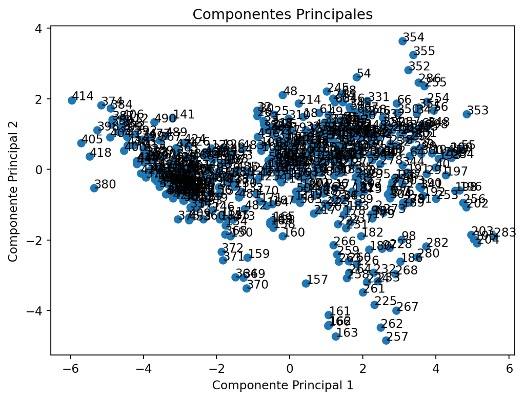

```python
acp_normado.plot()
```

Ahora se procede a hacer el círculo de correlaciones

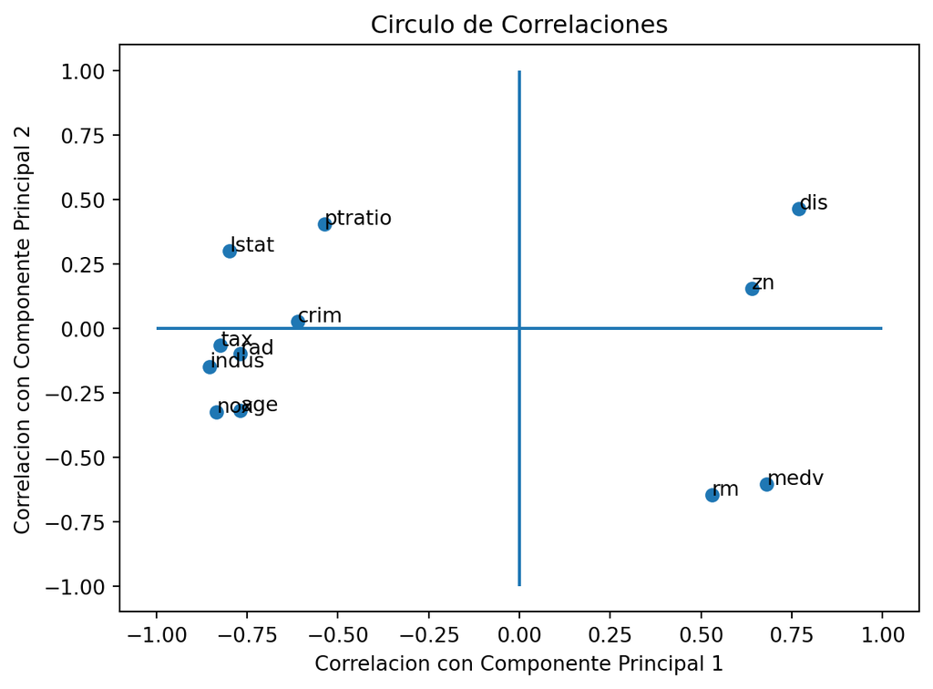

```python
acp_normado.circle_correlation()
```

En este caso se puede observar que `crim` es una variable que se ve claramente reflejada en la primera componente, pero no así en la segunda componente. Además, lo mismo sucede con los `rax`, `rad` y `indus` que podríamos decir que se encuentran claramente correlacionadas. Existen otras variables que se encuentran menos correlacionadas con estas comentadas anteriormente.